# Sdof solvers

## 1 Time domain solvers

The package provides a set of solvers to compute the time response of a single-degree-of-freedom (sdof) system.

### 1.1 Free response

The free response of a sdof system is the response of the system when it is subjected to initial conditions only. This means that the displacement of the mass is solution of the following ordinary differential equation:
$$\begin{cases}
\ddot x(t) + 2 \xi\omega_0\dot x(t) + \omega_0^2 x(t) = 0 \\
x(0) = x_0 \\
\dot x(0) = v_0
\end{cases}.$$

Depending on the value of the damping ratio $\xi$ and $\omega_0 > 0$, the system can have 4 different types of free response:

- an undamped motion when $\xi = 0$. In this case, the free response is:
  $$x(t) = x_0\cos\omega_0 t + \frac{v_0}{\omega_0}\sin\omega_0 t$$
- an underdamped motion when $0 < \xi < 1$. In this case, the free response is:
  $$x(t) = \left[x_0\cos\Omega_0 t + \frac{v_0 + \xi\Omega_0 x_0}{\Omega_0}\sin\Omega_0 t\right]e^{-\xi\omega_0 t}$$
  where $\Omega_0 = \omega_0\sqrt{1 - \xi^2}$.
- a critically damped motion when $\xi = 1$. In this case, the free response is:
  $$x(t) = \left[x_0 + (v_0 + \omega_0 x_0)t\right]e^{-\omega_0 t}$$
- an overdamped motion when $\xi > 1$. In this case, the free response is:
  $$x(t) = \left[x_0\text{cosh}(\beta t) + \frac{v_0 + \xi\omega_0 x_0}{\beta}\text{sinh}\beta t\right]e^{-\xi\omega_0 t},$$
  where $\beta = \omega_0\sqrt{\xi^2 - 1}$.

Finally, if $\omega = 0$, the mass is free from constraints and the free response is:
$$x(t) = x_0 + v_0 t.$$

#### 1.1.1 API

**Data type**

**SdofFreeTimeProblem**

```
SdofFreeTimeProblem(sdof, u0, t)
```

Structure containing the data of a time problem for a sdof system

**Fields**

- `sdof::Sdof`: Sdof structure

- `u0::AbstractVector`: Initial conditions

  - `x0`: Initial displacement [m]

  - `v0`: Initial velocity [m/s]

- `t::AbstractRange`: Time points at which to evaluate the response

**Related function**

**solve**

```
solve(prob::SdofFreeTimeProblem)
```

Compute the free response of a single degree of freedom (Sdof) system.

**Input**

- `prob`: Structure containing the parameters of the Sdof problem

**Output**

- `sol`: The response of the system at the given time points

  - `u`: Displacement solution

  - `du`: Velocity solution

  - `ddu`: Acceleration solution

#### 1.1.2 Example

```julia
# Structural parameters
m = 1.
f0 = 1.

# Time vector
t = 0.:0.01:10.

# Initial conditions
u0 = [1., -2.]

# Undamped system
sdof_nd = Sdof(m, f0, 0.)
prob_nd = SdofFreeTimeProblem(sdof_nd, u0, t)
x_nd = solve(prob_nd).u

# Underdamped system
sdof_ud = Sdof(m, f0, 0.1)
prob_ud = SdofFreeTimeProblem(sdof_ud, u0, t)
x_ud = solve(prob_ud).u

# Critically damped system
sdof_cd = Sdof(m, f0, 1.)
prob_cd = SdofFreeTimeProblem(sdof_cd, u0, t)
x_cd = solve(prob_cd).u

# Overdamped system
sdof_od = Sdof(m, f0, 1.2)
prob_od = SdofFreeTimeProblem(sdof_od, u0, t)
x_od = solve(prob_od).u;
```

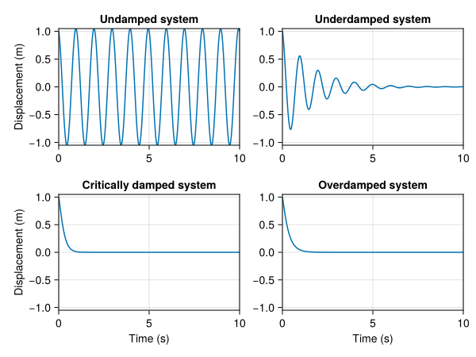

### 1.2 Forced response

The forced response of a sdof system is the response of the system is the solution of the following ordinary differential equation:
$$\begin{cases}
\ddot x(t) + 2 \xi\omega_0\dot x(t) + \omega_0^2 x(t) = \displaystyle\frac{\text{rhs}(t)}{m} \\
x(0) = x_0 \\
\dot x(0) = v_0
\end{cases},$$
where $\text{rhs}(t)$ is the right-hand side of the equation and its expression depends on the type of excitation:
$$\text{rhs}(t) = \begin{cases}
f(t) & \text{for an external force excitation} \\
m\omega_0^2 x_b(t) + 2\xi\omega_0m\dot x_b(t) & \text{for a base excitation}
\end{cases}.$$

Finally, the solution of the forced response is expressed as the sum of two terms, since:
$$x(t) = x_h(t) + x_p(t),$$
where $x_h(t)$ is the homogeneous solution of the equation and $x_p(t)$ is the particular solution of the equation.

#### 1.2.1 Harmonic excitation

When the excitation is harmonic, the resolution process is the following:

1. Compute the particular solution of the equation. The particular solution is a harmonic function of the same frequency as the excitation.
2. Express the general solution of the homogeneous equation.
3. Compute the remaining constants using the initial conditions. These constants depends on $x_p(0)$ and $\dot x_p(0)$.

##### 1.2.1.1 API

**Data type**

**SdofHarmonicTimeProblem**

```
SdofHarmonicTimeProblem(sdof, u0, t, F, ω, type_exc)
```

Structure containing the data of a time problem for a sdof system subject to a harmonic excitation

**Constructor parameters**

- `sdof::Sdof`: Sdof structure

- `F`: Amplitude of the force excitation [N] or base motion [m]

- `f`: Frequency of the excitation [Hz]

- `u0::AbstractVector`: Initial conditions

  - `x0`: Initial displacement [m]

  - `v0`: Initial velocity [m/s]

- `t::AbstractRange`: Time points at which to evaluate the response

- `type_exc::Symbol`: Type of excitation

  - `:force`: External force (default)

  - `:base`: Base motion

**Fields**

- `sdof::Sdof`: Sdof structure

- `F`: Amplitude of the force excitation [N] or base motion [m]

- `ω`: Frequency of the excitation [rad/s]

- `u0::AbstractVector`: Initial conditions

  - `x0`: Initial displacement [m]

  - `v0`: Initial velocity [m/s]

- `t::AbstractRange`: Time points at which to evaluate the response

- `type_exc::Symbol`: Type of excitation

  - `:force`: External force (default)

  - `:base`: Base motion

**Related function**

**solve**

```
solve(prob::SdofHarmonicTimeProblem)
```

Computes the forced response of a single degree of freedom (Sdof) system due to an harmonic external force or base motion

**Inputs**

- `prob`: Structure containing the parameters of the Sdof harmonic problem

**Output**

- `sol`: The response of the system at the given time points

  - `u`: Displacement solution

  - `du`: Velocity solution

  - `ddu`: Acceleration solution

##### 1.2.1.2 Example

```julia
# Structural parameters
m = 1.
f0 = 1.
ξ = 0.1

# Instantiation of the Sdof object
sdof = Sdof(m, f0, ξ)

# Harmonic excitation - Force amplitude + excitation frequency
F0 = 10.
f = 2.

# Instantiation of the problem
t = 0.:0.01:10.
u0 = [1., -2.]
prob = SdofHarmonicTimeProblem(sdof, u0, t, F0, f, :force)

# Solve the problem
x_harmo = solve(prob).u
```

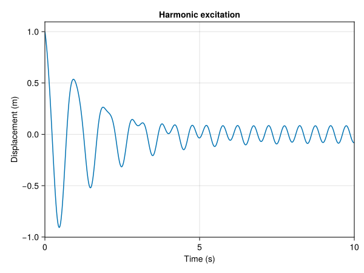

#### 1.2.2 Arbitrary excitation

For an arbitrary excitation, the solution is given by:
$$x(t) = x_\text{free}(t) + \int_0^t rhs(t - τ)h(τ)dτ,$$
where $x_\text{free}(t)$ is the free response of the system and $h(t)$ is the impulse response of the system.

##### 1.2.2.1 API

**Data type**

**SdofForcedTimeProblem**

```
SdofForcedTimeProblem(sdof, u0, t, F, ω, type_exc)
```

Structure containing the data of a time problem for a sdof system subject to an arbitrary excitation

**Fields**

- `sdof::Sdof`: Sdof structure

- `F::AbstractVector`: Amplitude of the force excitation [N] or base motion [m]

- `u0::AbstractVector`: Initial conditions

  - `x0`: Initial displacement [m]

  - `v0`: Initial velocity [m/s]

- `t::AbstractRange`: Time points at which to evaluate the response

- `type_exc::Symbol`: Type of excitation

  - `:force`: External force (default)

  - `:base`: Base motion

**Related function**

**solve**

```
solve(prob::SdofForcedTimeProblem)
```

Computes the forced response of a single degree of freedom (Sdof) system due to an arbitrary external force or base motion

**Inputs**

- `prob`: Structure containing the parameters of the Sdof forced problem

- `method`: Method to compute the Duhamel's integral

  - `:filt`: Filtering using the Z-transform of the impulse response (default)

  - `:interp`: Interpolation + Gaussian quadrature

  - `:conv`: Convolution product

**Output**

- `sol`: The response of the system at the given time points

  - `u`: Displacement solution

  - `du`: Velocity solution

  - `ddu`: Acceleration solution

##### 1.2.2.2 Example

```julia
# Structural parameters
m = 1.
f0 = 1.
ξ = 0.1

# Instantiation of the Sdof object
sdof = Sdof(m, f0, ξ)

# Haversine excitation signal
F0 = 10.
tstart = 0.5
duration = 2.
haversine = HaverSine(F0, tstart, duration)

t = 0.:0.01:10.
F = excitation(haversine, t)

# Instantiation of the problem
u0 = [1, -2]
prob = SdofForcedTimeProblem(sdof, u0, t, F, :force)

# Solve the problem
x_arb_filt = solve(prob, method = :filt).u
x_arb_interp = solve(prob, method = :interp).u
x_arb_conv = solve(prob, method = :conv).u;
```

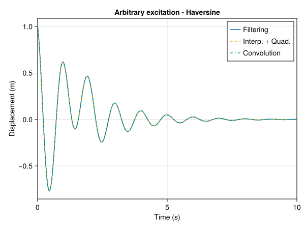

### 1.3 Additional functions

#### 1.3.1 Impulse response

The impulse response of a sdof system is the response of the system when it is subjected to an impulse excitation. The impulse response is the solution of the following ordinary differential equation:
$$\overset{..}{h}(t) + 2\xi\omega_0\overset{.}{h}(t) + \omega_0^2 h(t) = \frac{\delta(t)}{m}.$$

It can be shown that the impulse response can be computed by solving the following problem:
$$\begin{cases}
\overset{..}{h}(t) + 2\xi\omega_0\overset{.}{h}(t) + \omega_0^2 h(t) = 0 & \forall t > 0 \\
h(t) = 0 & \text{at } t = 0 \\
\overset{.}{h}(t) = \displaystyle\frac{1}{m} & \text{at } t = 0
\end{cases}.$$

**impulse_response**

```
impulse_response(sdof, t)
```

Compute the impulse response of a single degree of freedom (Sdof) system

**Inputs**

- `sdof`: Sdof structure

- `t`: Time points at which to evaluate the response

**Output**

- `h`: Impulse response

```julia
# Structural parameters
m = 1.
f0 = 1.
ξ = 0.1

t = 0.:0.01:10.

# Instantiation of the Sdof object
sdof = Sdof(m, f0, ξ)

h = impulse_response(sdof, t)
```

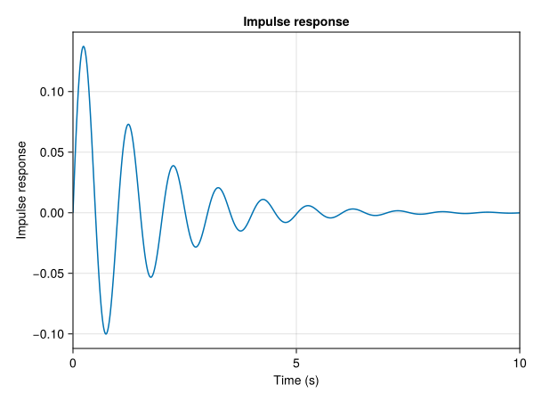

#### 1.3.2 Shock response spectrum

The shock response spectrum (SRS) is a graph of the peak acceleration response of a sdof system subjected to a base acceleration with respect to the frequency. The SRS is computed by solving the following problem:
$$\ddot z(t) + 2\xi\omega_0\dot z(t) + \omega_0^2 z(t) = -\ddot x_b(t),$$
where $z(t) = x(t) - x_b(t)$ is the relative displacement of the system with respect to the base.

To compute the SRS, the following steps are performed at a given frequency $f$:

1. Instantiate a Sdof type

   ```julia
   sdof = Sdof(1., f, ξ)
   ```

2. Compute the time response of the relative displacement $z(t)$ due to a base acceleration for $z(0) = 0$ and $\dot z(0) = 0$.
3. Compute the acceleration $\ddot x(t)$ of the system:
   $$x(t) = -2\xi\omega_0\dot z(t) - \omega_0^2 z(t)$$
4. Extract the primary or secondary part of the acceleration (i.e. until or after the end of the excitation signal).
5. Compute either:
   - The peak acceleration of the system such that:
     $$SRS(f) = \max\left(|\ddot x(t)|\right)$$
   - The maximum positive acceleration of the system such that:
     $$SRS(f) = \max\left(\max(\ddot x(t), 0)\right)$$
   - The maximum negative acceleration of the system such that:
     $$SRS(f) = \max\left(\max(-\ddot x(t), 0)\right)$$

Several algorithms are available to compute the SRS:

- `:Basic`: the SRS is computed by following the steps mentioned above. It is not the most efficient algorithm but it is the most versatile.
- `:RecursiveInt`: the SRS is computed using a recursive integration algorithm.
- `:RecursiveFilt`: the SRS is computed using a recursive filtering algorithm.
- `:Smallwood`: the SRS is computed using the Smallwood algorithm.

For the last three algorithms, more details and references can be found [Mathworks - Introduction to SRS](https://fr.mathworks.com/help/signal/ug/practical-introduction-to-shock-waveform-and-shock-response-spectrum.html)

**srs**

```
srs(base_acc::ArbitraryExc, freq, t, ξ = 0.05,
    type = (instance = :primary, amplitude = :abs), alg = :Smallwood)
```

Compute the Shock Response Spectrum (SRS)

**Inputs**

- `base_acc::ArbitraryExc`: Base acceleration type - see `excitation` function for detatils

- `freq`: Vector of frequencies [Hz]

- `t`: Time points at which to evaluate the response

- `ξ`: Damping ratio (default = 0.05)

- `type`: Type of SRS

  - `instance`: Instance of the SRS

    - `:primary`: Primary instance (default)

    - `:secondary`: Secondary instance

  - `amplitude`: Amplitude used of the computing SRS

    - `:abs`: Maximum absolute amplitude (default)

    - `:pos`: Maximum positive amplitude

    - `:neg`: Maximum negative amplitude

- `alg`: Algorithm to compute the SRS

  - `:Basic`: Basic algorithm

  - `:RecursiveInt`: Recursive integration algorithm

  - `:RecursiveFilt`: Recursive filtering algorithm

  - `:Smallwood`: Smallwood algorithm (default)

**Output**

- `srs`: Vector of the SRS values

*Note*

- Primary instance - response of the system during the application of the base acceleration

- Secondary instance - response of the system after the application of the base acceleration

```julia
# Definition of the base acceleration
t = 0.:1e-5:0.5
base_acc = HalfSine(10., 0., 1e-3)

# Compute the SRS
f = 50.:25:1e3
srs_basic = srs(base_acc, f, t)
srs_rec_int = srs(base_acc, f, t, alg = :RecursiveInt)
srs_rec_filt = srs(base_acc, f, t, alg = :RecursiveFilt)
srs_smallwood = srs(base_acc, f, t, alg = :Smallwood)
```

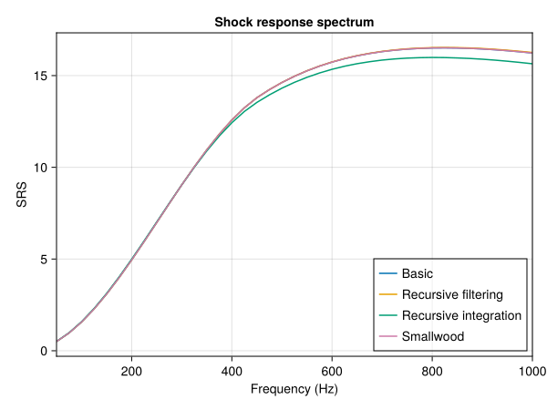

## 2 Frequency domain solvers

The package provides solvers for computing the Frequency Response Function (FRF) and the response spectrum of a sdof system.

### 2.1 Frequency Response Function

The Frequency Response Function (FRF) of a sdof system is the ratio of the steady-state response $X(\omega)$ of the system to an external excitation $F(\omega)$ or an external base motion $X_b(\omega)$. The FRF is computed from the following equation:
$$H(\omega) = \begin{cases}
\displaystyle\frac{1}{m(\omega_0^2 - \omega^2 + 2j\xi\omega\omega_0)} & \text{for a force excitation} \\
\displaystyle\frac{\omega_0^2 + 2j\xi\omega\omega_0}{\omega_0^2 - \omega^2 + 2j\xi\omega\omega_0} & \text{for a base excitation}
\end{cases},$$
where $j$ is the imaginary unit.

#### 2.1.1 API

**Data type**

**SdofFRFProblem**

```
SdofFRFProblem(sdof, freq, type_exc, type_resp)
```

Structure containing the data for computing the FRF a sdof system

**Fields**

- `sdof::Sdof`: Sdof structure

- `freq::AbstractRange`: Vector of frequencies [Hz]

- `type_exc::Symbol`: Type of excitation

  - `:force`: External force (default)

  - `:base`: Base motion

- `type_resp::Symbol`: Type of response

  - `:dis`: Admittance (default)

  - `:vel`: Mobility

  - `:acc`: Accelerance

**Related function**

**solve**

```
solve(prob::SdofFRFProblem)
```

Compute the FRF of a single degree of freedom (Sdof) system

**Inputs**

- `prob`: Structure containing the parameters of the Sdof FRF problem

**Output**

- `sol`: Solution of the FRF problem

  - `u`: FRF of the system

#### 2.1.2 Example

```julia
# Structural parameters
m = 1.
f0 = 10.
ξ = 0.01

# Instantiation of the Sdof object
sdof = Sdof(m, f0, ξ)

# Definition of the frequency range
f = 1.:0.1:30.

# Instantiation of the problem - Force excitation
prob = SdofFRFProblem(sdof, f)

# Solve the problem
H = solve(prob).u
```

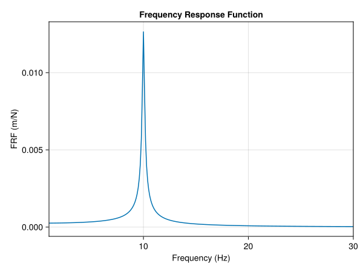

### 2.2 Response spectrum

The response spectrum of a sdof system is the frequency response of the system to an external force $F(\omega)$ or a base motion $X_b(\omega)$ with respect to the frequency. The response spectrum $Y(\omega)$ is computed from the following equation:
$$Y(\omega) = \begin{cases}
\displaystyle\frac{F(\omega)}{m(\omega_0^2 - \omega^2 + 2j\xi\omega\omega_0)} & \text{for a force excitation} \\
\displaystyle\frac{(\omega_0^2 + 2j\xi\omega\omega_0) X_b(\omega)}{\omega_0^2 - \omega^2 + 2j\xi\omega\omega_0} & \text{for a base excitation}
\end{cases}.$$

#### 2.2.1 API

**Data type**

```
SdofFrequencyProblem(sdof, F, type_exc, type_resp)
```

Structure containing the data for computing the frequency response of a sdof system

**Fields**

- `sdof::Sdof`: Sdof structure

- `freq::AbstractRange`: Vector of frequencies [Hz]

- `F::AbstractVector`: Vector of the force excitation [N] or base motion [m]

- `type_exc::Symbol`: Type of excitation

  - `:force`: External force (default)

  - `:base`: Base motion

- `type_resp::Symbol`: Type of response

  - `:dis`: Displacement spectrum(default)

  - `:vel`: Velocity spectrum

  - `:acc`: Acceleration spectrum

**Related function**

**solve**

```
solve(prob::SdofFRFProblem)
```

Compute the FRF of a single degree of freedom (Sdof) system

**Inputs**

- `prob`: Structure containing the parameters of the Sdof FRF problem

**Output**

- `sol`: Solution of the FRF problem

  - `u`: FRF of the system

#### 2.2.2 Example

```julia
# Structural parameters
m = 1.
f0 = 10.
ξ = 0.01

# Instantiation of the Sdof object
sdof = Sdof(m, f0, ξ)

# Definition of the frequency range
f = 1.:0.1:30.

# Instantiation of the problem - Force excitation
F = fill(10., length(f))
prob = SdofFrequencyProblem(sdof, f, F)

# Solve the problem
y = solve(prob).u
```

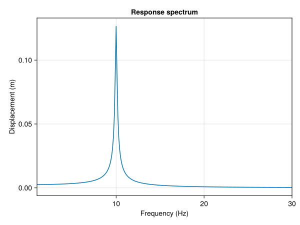